# Setup and Context

### Introduction

On November 27, 1895, Alfred Nobel signed his last will in Paris. When it was opened after his death, the will caused a lot of controversy, as Nobel had left much of his wealth for the establishment of a prize.

Alfred Nobel dictates that his entire remaining estate should be used to endow “prizes to those who, during the preceding year, have conferred the greatest benefit to humankind”.

Every year the Nobel Prize is given to scientists and scholars in the categories chemistry, literature, physics, physiology or medicine, economics, and peace.

[figure not shown]

Let's see what patterns we can find in the data of the past Nobel laureates. What can we learn about the Nobel prize and our world more generally?

### Upgrade plotly (only Google Colab Notebook)

Google Colab may not be running the latest version of plotly. If you're working in Google Colab, uncomment the line below, run the cell, and restart your notebook server.

```python
# %pip install --upgrade plotly
```

### Import Statements

```python
import pandas as pd
import numpy as np
import plotly.express as px
import seaborn as sns
import matplotlib.pyplot as plt
```

### Notebook Presentation

```python
pd.options.display.float_format = '{:,.2f}'.format
```

### Read the Data

```python
df_data = pd.read_csv('nobel_prize_data.csv')
```

Caveats: The exact birth dates for Michael Houghton, Venkatraman Ramakrishnan, and Nadia Murad are unknown. I've substituted them with mid-year estimate of July 2nd.

# Data Exploration & Cleaning

**Challenge**: Preliminary data exploration.

- What is the shape of `df_data`? How many rows and columns?
- What are the column names?
- In which year was the Nobel prize first awarded?
- Which year is the latest year included in the dataset?

```python
df_data.shape
```

```
(962, 16)
```

```python
df_data.columns
```

```
Index(['year', 'category', 'prize', 'motivation', 'prize_share',
       'laureate_type', 'full_name', 'birth_date', 'birth_city',
       'birth_country', 'birth_country_current', 'sex', 'organization_name',
       'organization_city', 'organization_country', 'ISO'],
      dtype='object')
```

```python
df_data = df_data.sort_values('year')
```

```python
df_data.head()
```

|  | year | category | prize | motivation | prize_share | laureate_type | full_name | birth_date | birth_city | birth_country | birth_country_current | sex | organization_name | organization_city | organization_country | ISO |
| --- | --- | --- | --- | --- | --- | --- | --- | --- | --- | --- | --- | --- | --- | --- | --- | --- |
| 0 | 1901 | Chemistry | The Nobel Prize in Chemistry 1901 | "in recognition of the extraordinary services ... | 1/1 | Individual | Jacobus Henricus van 't Hoff | 1852-08-30 | Rotterdam | Netherlands | Netherlands | Male | Berlin University | Berlin | Germany | NLD |
| 1 | 1901 | Literature | The Nobel Prize in Literature 1901 | "in special recognition of his poetic composit... | 1/1 | Individual | Sully Prudhomme | 1839-03-16 | Paris | France | France | Male | NaN | NaN | NaN | FRA |
| 2 | 1901 | Medicine | The Nobel Prize in Physiology or Medicine 1901 | "for his work on serum therapy, especially its... | 1/1 | Individual | Emil Adolf von Behring | 1854-03-15 | Hansdorf (Lawice) | Prussia (Poland) | Poland | Male | Marburg University | Marburg | Germany | POL |
| 3 | 1901 | Peace | The Nobel Peace Prize 1901 | NaN | 1/2 | Individual | Frédéric Passy | 1822-05-20 | Paris | France | France | Male | NaN | NaN | NaN | FRA |
| 4 | 1901 | Peace | The Nobel Peace Prize 1901 | NaN | 1/2 | Individual | Jean Henry Dunant | 1828-05-08 | Geneva | Switzerland | Switzerland | Male | NaN | NaN | NaN | CHE |

```python
df_data.tail()
```

|  | year | category | prize | motivation | prize_share | laureate_type | full_name | birth_date | birth_city | birth_country | birth_country_current | sex | organization_name | organization_city | organization_country | ISO |
| --- | --- | --- | --- | --- | --- | --- | --- | --- | --- | --- | --- | --- | --- | --- | --- | --- |
| 951 | 2020 | Chemistry | The Nobel Prize in Chemistry 2020 | “for the development of a method for genome ed... | 1/2 | Individual | Jennifer A. Doudna | 1964-02-19 | Washington, DC | United States of America | United States of America | Female | University of California | Berkeley, CA | United States of America | USA |
| 950 | 2020 | Chemistry | The Nobel Prize in Chemistry 2020 | “for the development of a method for genome ed... | 1/2 | Individual | Emmanuelle Charpentier | 1968-12-11 | Juvisy-sur-Orge | France | France | Female | Max-Planck-Institut | Berlin | Germany | FRA |
| 960 | 2020 | Physics | The Nobel Prize in Physics 2020 | “for the discovery of a supermassive compact o... | 1/4 | Individual | Reinhard Genzel | 1952-03-24 | Bad Homburg vor der Höhe | Germany | Germany | Male | University of California | Los Angeles, CA | United States of America | DEU |
| 954 | 2020 | Literature | The Nobel Prize in Literature 2020 | “for her unmistakable poetic voice that with a... | 1/1 | Individual | Louise Glück | 1943-04-22 | New York, NY | United States of America | United States of America | Female | NaN | NaN | NaN | USA |
| 961 | 2020 | Physics | The Nobel Prize in Physics 2020 | “for the discovery that black hole formation i... | 1/2 | Individual | Roger Penrose | 1931-08-08 | Colchester | United Kingdom | United Kingdom | Male | University of Oxford | Oxford | United Kingdom | GBR |

**Challange**:

- Are there any duplicate values in the dataset?
- Are there NaN values in the dataset?
- Which columns tend to have NaN values?
- How many NaN values are there per column?
- Why do these columns have NaN values?

### Check for Duplicates

```python
df_data.duplicated().values.any()
```

```
False
```

### Check for NaN Values

```python
df_data.isna().values.any()
```

```
True
```

```python
df_data.isna().sum()
```

```
year                       0
category                   0
prize                      0
motivation                88
prize_share                0
laureate_type              0
full_name                  0
birth_date                28
birth_city                31
birth_country             28
birth_country_current     28
sex                       28
organization_name        255
organization_city        255
organization_country     254
ISO                       28
dtype: int64
```

```python
col_subset = ['year', 'category', 'laureate_type', 'birth_date', 'full_name', 'organization_name']
df_data.loc[df_data['birth_date'].isna()][col_subset]
```

|  | year | category | laureate_type | birth_date | full_name | organization_name |
| --- | --- | --- | --- | --- | --- | --- |
| 24 | 1904 | Peace | Organization | NaN | Institut de droit international (Institute of ... | NaN |
| 60 | 1910 | Peace | Organization | NaN | Bureau international permanent de la Paix (Per... | NaN |
| 89 | 1917 | Peace | Organization | NaN | Comité international de la Croix Rouge (Intern... | NaN |
| 200 | 1938 | Peace | Organization | NaN | Office international Nansen pour les Réfugiés ... | NaN |
| 215 | 1944 | Peace | Organization | NaN | Comité international de la Croix Rouge (Intern... | NaN |
| 237 | 1947 | Peace | Organization | NaN | American Friends Service Committee (The Quakers) | NaN |
| 238 | 1947 | Peace | Organization | NaN | Friends Service Council (The Quakers) | NaN |
| 283 | 1954 | Peace | Organization | NaN | Office of the United Nations High Commissioner... | NaN |
| 348 | 1963 | Peace | Organization | NaN | Comité international de la Croix Rouge (Intern... | NaN |
| 349 | 1963 | Peace | Organization | NaN | Ligue des Sociétés de la Croix-Rouge (League o... | NaN |
| 366 | 1965 | Peace | Organization | NaN | United Nations Children's Fund (UNICEF) | NaN |
| 399 | 1969 | Peace | Organization | NaN | International Labour Organization (I.L.O.) | NaN |
| 479 | 1977 | Peace | Organization | NaN | Amnesty International | NaN |
| 523 | 1981 | Peace | Organization | NaN | Office of the United Nations High Commissioner... | NaN |
| 558 | 1985 | Peace | Organization | NaN | International Physicians for the Prevention of... | NaN |
| 588 | 1988 | Peace | Organization | NaN | United Nations Peacekeeping Forces | NaN |
| 659 | 1995 | Peace | Organization | NaN | Pugwash Conferences on Science and World Affairs | NaN |
| 682 | 1997 | Peace | Organization | NaN | International Campaign to Ban Landmines (ICBL) | NaN |
| 703 | 1999 | Peace | Organization | NaN | Médecins Sans Frontières | NaN |
| 730 | 2001 | Peace | Organization | NaN | United Nations (U.N.) | NaN |
| 778 | 2005 | Peace | Organization | NaN | International Atomic Energy Agency (IAEA) | NaN |
| 788 | 2006 | Peace | Organization | NaN | Grameen Bank | NaN |
| 801 | 2007 | Peace | Organization | NaN | Intergovernmental Panel on Climate Change (IPCC) | NaN |
| 860 | 2012 | Peace | Organization | NaN | European Union (EU) | NaN |
| 873 | 2013 | Peace | Organization | NaN | Organisation for the Prohibition of Chemical W... | NaN |
| 897 | 2015 | Peace | Organization | NaN | National Dialogue Quartet | NaN |
| 919 | 2017 | Peace | Organization | NaN | International Campaign to Abolish Nuclear Weap... | NaN |
| 958 | 2020 | Peace | Organization | NaN | World Food Programme (WFP) | NaN |

### Type Conversions

**Challenge**:

- Convert the `birth_date` column to Pandas `Datetime` objects
- Add a Column called `share_pct` which has the laureates' share as a percentage in the form of a floating-point number.

#### Convert Year and Birth Date to Datetime

```python
df_data['birth_date'] = pd.to_datetime(df_data['birth_date'])
```

```python
df_data.head()
```

|  | year | category | prize | motivation | prize_share | laureate_type | full_name | birth_date | birth_city | birth_country | birth_country_current | sex | organization_name | organization_city | organization_country | ISO |
| --- | --- | --- | --- | --- | --- | --- | --- | --- | --- | --- | --- | --- | --- | --- | --- | --- |
| 0 | 1901 | Chemistry | The Nobel Prize in Chemistry 1901 | "in recognition of the extraordinary services ... | 1/1 | Individual | Jacobus Henricus van 't Hoff | 1852-08-30 | Rotterdam | Netherlands | Netherlands | Male | Berlin University | Berlin | Germany | NLD |
| 1 | 1901 | Literature | The Nobel Prize in Literature 1901 | "in special recognition of his poetic composit... | 1/1 | Individual | Sully Prudhomme | 1839-03-16 | Paris | France | France | Male | NaN | NaN | NaN | FRA |
| 2 | 1901 | Medicine | The Nobel Prize in Physiology or Medicine 1901 | "for his work on serum therapy, especially its... | 1/1 | Individual | Emil Adolf von Behring | 1854-03-15 | Hansdorf (Lawice) | Prussia (Poland) | Poland | Male | Marburg University | Marburg | Germany | POL |
| 3 | 1901 | Peace | The Nobel Peace Prize 1901 | NaN | 1/2 | Individual | Frédéric Passy | 1822-05-20 | Paris | France | France | Male | NaN | NaN | NaN | FRA |
| 4 | 1901 | Peace | The Nobel Peace Prize 1901 | NaN | 1/2 | Individual | Jean Henry Dunant | 1828-05-08 | Geneva | Switzerland | Switzerland | Male | NaN | NaN | NaN | CHE |

#### Add a Column with the Prize Share as a Percentage

```python
separated_values = df_data['prize_share'].str.split('/', expand=True)
numerator = pd.to_numeric(separated_values[0])
denomenator = pd.to_numeric(separated_values[1])
df_data['share_pct'] = numerator / denomenator * 100
```

```python
df_data.head()
```

|  | year | category | prize | motivation | prize_share | laureate_type | full_name | birth_date | birth_city | birth_country | birth_country_current | sex | organization_name | organization_city | organization_country | ISO | share_pct |
| --- | --- | --- | --- | --- | --- | --- | --- | --- | --- | --- | --- | --- | --- | --- | --- | --- | --- |
| 0 | 1901 | Chemistry | The Nobel Prize in Chemistry 1901 | "in recognition of the extraordinary services ... | 1/1 | Individual | Jacobus Henricus van 't Hoff | 1852-08-30 | Rotterdam | Netherlands | Netherlands | Male | Berlin University | Berlin | Germany | NLD | 100.00 |
| 1 | 1901 | Literature | The Nobel Prize in Literature 1901 | "in special recognition of his poetic composit... | 1/1 | Individual | Sully Prudhomme | 1839-03-16 | Paris | France | France | Male | NaN | NaN | NaN | FRA | 100.00 |
| 2 | 1901 | Medicine | The Nobel Prize in Physiology or Medicine 1901 | "for his work on serum therapy, especially its... | 1/1 | Individual | Emil Adolf von Behring | 1854-03-15 | Hansdorf (Lawice) | Prussia (Poland) | Poland | Male | Marburg University | Marburg | Germany | POL | 100.00 |
| 3 | 1901 | Peace | The Nobel Peace Prize 1901 | NaN | 1/2 | Individual | Frédéric Passy | 1822-05-20 | Paris | France | France | Male | NaN | NaN | NaN | FRA | 50.00 |
| 4 | 1901 | Peace | The Nobel Peace Prize 1901 | NaN | 1/2 | Individual | Jean Henry Dunant | 1828-05-08 | Geneva | Switzerland | Switzerland | Male | NaN | NaN | NaN | CHE | 50.00 |

# Plotly Donut Chart: Percentage of Male vs. Female Laureates

**Challenge**: Create a [donut chart using plotly](https://plotly.com/python/pie-charts/) which shows how many prizes went to men compared to how many prizes went to women. What percentage of all the prizes went to women?

```python
df_data.head()
```

|  | year | category | prize | motivation | prize_share | laureate_type | full_name | birth_date | birth_city | birth_country | birth_country_current | sex | organization_name | organization_city | organization_country | ISO | share_pct |
| --- | --- | --- | --- | --- | --- | --- | --- | --- | --- | --- | --- | --- | --- | --- | --- | --- | --- |
| 0 | 1901 | Chemistry | The Nobel Prize in Chemistry 1901 | "in recognition of the extraordinary services ... | 1/1 | Individual | Jacobus Henricus van 't Hoff | 1852-08-30 | Rotterdam | Netherlands | Netherlands | Male | Berlin University | Berlin | Germany | NLD | 100.00 |
| 1 | 1901 | Literature | The Nobel Prize in Literature 1901 | "in special recognition of his poetic composit... | 1/1 | Individual | Sully Prudhomme | 1839-03-16 | Paris | France | France | Male | NaN | NaN | NaN | FRA | 100.00 |
| 2 | 1901 | Medicine | The Nobel Prize in Physiology or Medicine 1901 | "for his work on serum therapy, especially its... | 1/1 | Individual | Emil Adolf von Behring | 1854-03-15 | Hansdorf (Lawice) | Prussia (Poland) | Poland | Male | Marburg University | Marburg | Germany | POL | 100.00 |
| 3 | 1901 | Peace | The Nobel Peace Prize 1901 | NaN | 1/2 | Individual | Frédéric Passy | 1822-05-20 | Paris | France | France | Male | NaN | NaN | NaN | FRA | 50.00 |
| 4 | 1901 | Peace | The Nobel Peace Prize 1901 | NaN | 1/2 | Individual | Jean Henry Dunant | 1828-05-08 | Geneva | Switzerland | Switzerland | Male | NaN | NaN | NaN | CHE | 50.00 |

```python
df_data.count()
```

```
year                     962
category                 962
prize                    962
motivation               874
prize_share              962
laureate_type            962
full_name                962
birth_date               934
birth_city               931
birth_country            934
birth_country_current    934
sex                      934
organization_name        707
organization_city        707
organization_country     708
ISO                      934
share_pct                962
dtype: int64
```

```python
female_winers = df_data[df_data['sex'] == 'Female'].sex.count()
```

```python
total_human_winer = df_data['sex'].dropna()
```

```python
total_human_winer = total_human_winer.count()
```

```python
female_winers_pct = female_winers / total_human_winer
```

```python
female_winers_pct
```

```
0.06209850107066381
```

```python
biology = df_data['sex'].value_counts()
```

```python
biology
```

```
Male      876
Female     58
Name: sex, dtype: int64
```

```python
fig = px.pie(labels=biology.index,
             values=biology.values,
             title='Pct of Male vs Female winner',
             names=biology.index,
             hole=0.4)

fig.update_traces(textposition='inside',
                  textfont_size=15,
                  textinfo='percent')

fig.show()
```

# Who were the first 3 Women to Win the Nobel Prize?

**Challenge**:

- What are the names of the first 3 female Nobel laureates?
- What did the win the prize for?
- What do you see in their `birth_country`? Were they part of an organisation?

```python
df_data[df_data['sex'] == 'Female'].sort_values('year')[:3]
```

|  | year | category | prize | motivation | prize_share | laureate_type | full_name | birth_date | birth_city | birth_country | birth_country_current | sex | organization_name | organization_city | organization_country | ISO | share_pct |
| --- | --- | --- | --- | --- | --- | --- | --- | --- | --- | --- | --- | --- | --- | --- | --- | --- | --- |
| 18 | 1903 | Physics | The Nobel Prize in Physics 1903 | "in recognition of the extraordinary services ... | 1/4 | Individual | Marie Curie, née Sklodowska | 1867-11-07 | Warsaw | Russian Empire (Poland) | Poland | Female | NaN | NaN | NaN | POL | 25.00 |
| 29 | 1905 | Peace | The Nobel Peace Prize 1905 | NaN | 1/1 | Individual | Baroness Bertha Sophie Felicita von Suttner, n... | 1843-06-09 | Prague | Austrian Empire (Czech Republic) | Czech Republic | Female | NaN | NaN | NaN | CZE | 100.00 |
| 51 | 1909 | Literature | The Nobel Prize in Literature 1909 | "in appreciation of the lofty idealism, vivid ... | 1/1 | Individual | Selma Ottilia Lovisa Lagerlöf | 1858-11-20 | Mårbacka | Sweden | Sweden | Female | NaN | NaN | NaN | SWE | 100.00 |

# Find the Repeat Winners

**Challenge**: Did some people get a Nobel Prize more than once? If so, who were they?

```python
df_data['full_name'].duplicated().values.any()
```

```
True
```

```python
multiple_winners = df_data[df_data['full_name'].duplicated(keep=False)]
```

```python
multiple_winners
```

|  | year | category | prize | motivation | prize_share | laureate_type | full_name | birth_date | birth_city | birth_country | birth_country_current | sex | organization_name | organization_city | organization_country | ISO | share_pct |
| --- | --- | --- | --- | --- | --- | --- | --- | --- | --- | --- | --- | --- | --- | --- | --- | --- | --- |
| 18 | 1903 | Physics | The Nobel Prize in Physics 1903 | "in recognition of the extraordinary services ... | 1/4 | Individual | Marie Curie, née Sklodowska | 1867-11-07 | Warsaw | Russian Empire (Poland) | Poland | Female | NaN | NaN | NaN | POL | 25.00 |
| 62 | 1911 | Chemistry | The Nobel Prize in Chemistry 1911 | "in recognition of her services to the advance... | 1/1 | Individual | Marie Curie, née Sklodowska | 1867-11-07 | Warsaw | Russian Empire (Poland) | Poland | Female | Sorbonne University | Paris | France | POL | 100.00 |
| 89 | 1917 | Peace | The Nobel Peace Prize 1917 | NaN | 1/1 | Organization | Comité international de la Croix Rouge (Intern... | NaT | NaN | NaN | NaN | NaN | NaN | NaN | NaN | NaN | 100.00 |
| 215 | 1944 | Peace | The Nobel Peace Prize 1944 | NaN | 1/1 | Organization | Comité international de la Croix Rouge (Intern... | NaT | NaN | NaN | NaN | NaN | NaN | NaN | NaN | NaN | 100.00 |
| 283 | 1954 | Peace | The Nobel Peace Prize 1954 | NaN | 1/1 | Organization | Office of the United Nations High Commissioner... | NaT | NaN | NaN | NaN | NaN | NaN | NaN | NaN | NaN | 100.00 |
| 278 | 1954 | Chemistry | The Nobel Prize in Chemistry 1954 | "for his research into the nature of the chemi... | 1/1 | Individual | Linus Carl Pauling | 1901-02-28 | Portland, OR | United States of America | United States of America | Male | California Institute of Technology (Caltech) | Pasadena, CA | United States of America | USA | 100.00 |
| 297 | 1956 | Physics | The Nobel Prize in Physics 1956 | "for their researches on semiconductors and th... | 1/3 | Individual | John Bardeen | 1908-05-23 | Madison, WI | United States of America | United States of America | Male | University of Illinois | Urbana, IL | United States of America | USA | 33.33 |
| 306 | 1958 | Chemistry | The Nobel Prize in Chemistry 1958 | "for his work on the structure of proteins, es... | 1/1 | Individual | Frederick Sanger | 1918-08-13 | Rendcombe | United Kingdom | United Kingdom | Male | University of Cambridge | Cambridge | United Kingdom | GBR | 100.00 |
| 340 | 1962 | Peace | The Nobel Peace Prize 1962 | NaN | 1/1 | Individual | Linus Carl Pauling | 1901-02-28 | Portland, OR | United States of America | United States of America | Male | California Institute of Technology (Caltech) | Pasadena, CA | United States of America | USA | 100.00 |
| 348 | 1963 | Peace | The Nobel Peace Prize 1963 | NaN | 1/2 | Organization | Comité international de la Croix Rouge (Intern... | NaT | NaN | NaN | NaN | NaN | NaN | NaN | NaN | NaN | 50.00 |
| 424 | 1972 | Physics | The Nobel Prize in Physics 1972 | "for their jointly developed theory of superco... | 1/3 | Individual | John Bardeen | 1908-05-23 | Madison, WI | United States of America | United States of America | Male | University of Illinois | Urbana, IL | United States of America | USA | 33.33 |
| 505 | 1980 | Chemistry | The Nobel Prize in Chemistry 1980 | "for their contributions concerning the determ... | 1/4 | Individual | Frederick Sanger | 1918-08-13 | Rendcombe | United Kingdom | United Kingdom | Male | MRC Laboratory of Molecular Biology | Cambridge | United Kingdom | GBR | 25.00 |
| 523 | 1981 | Peace | The Nobel Peace Prize 1981 | NaN | 1/1 | Organization | Office of the United Nations High Commissioner... | NaT | NaN | NaN | NaN | NaN | NaN | NaN | NaN | NaN | 100.00 |

```python
is_winner = df_data.duplicated(subset=['full_name'], keep=False)
multiple_winners = df_data[is_winner]
print(f'There are {multiple_winners.full_name.nunique()}' \
      ' winners who were awarded the prize more than once.')
```

```
There are 6 winners who were awarded the prize more than once.
```

```python
col_subset = ['year', 'category', 'laureate_type', 'full_name']
multiple_winners[col_subset]
```

|  | year | category | laureate_type | full_name |
| --- | --- | --- | --- | --- |
| 18 | 1903 | Physics | Individual | Marie Curie, née Sklodowska |
| 62 | 1911 | Chemistry | Individual | Marie Curie, née Sklodowska |
| 89 | 1917 | Peace | Organization | Comité international de la Croix Rouge (Intern... |
| 215 | 1944 | Peace | Organization | Comité international de la Croix Rouge (Intern... |
| 283 | 1954 | Peace | Organization | Office of the United Nations High Commissioner... |
| 278 | 1954 | Chemistry | Individual | Linus Carl Pauling |
| 297 | 1956 | Physics | Individual | John Bardeen |
| 306 | 1958 | Chemistry | Individual | Frederick Sanger |
| 340 | 1962 | Peace | Individual | Linus Carl Pauling |
| 348 | 1963 | Peace | Organization | Comité international de la Croix Rouge (Intern... |
| 424 | 1972 | Physics | Individual | John Bardeen |
| 505 | 1980 | Chemistry | Individual | Frederick Sanger |
| 523 | 1981 | Peace | Organization | Office of the United Nations High Commissioner... |

# Number of Prizes per Category

**Challenge**:

- In how many categories are prizes awarded?
- Create a plotly bar chart with the number of prizes awarded by category.
- Use the color scale called `Aggrnyl` to colour the chart, but don't show a color axis.
- Which category has the most number of prizes awarded?
- Which category has the fewest number of prizes awarded?

```python
df_data['category'].nunique()
```

```
6
```

```python
category_pie = df_data['category'].value_counts()
```

```python
fig = px.bar(x=category_pie.index,
             y=category_pie.values,
             title='Num of Winner in each Category',
             color=category_pie.values,
             color_continuous_scale='Aggrnyl',
             )

fig.update_layout(xaxis_title='Nobel Prize Category',
                    coloraxis_showscale=False,
                    yaxis_title='Number of Prizes')

fig.show()
```

**Challenge**:

- When was the first prize in the field of Economics awarded?
- Who did the prize go to?

```python
df_data[df_data['category'] == 'Economics'].sort_values('year').head()
```

|  | year | category | prize | motivation | prize_share | laureate_type | full_name | birth_date | birth_city | birth_country | birth_country_current | sex | organization_name | organization_city | organization_country | ISO | share_pct |
| --- | --- | --- | --- | --- | --- | --- | --- | --- | --- | --- | --- | --- | --- | --- | --- | --- | --- |
| 393 | 1969 | Economics | The Sveriges Riksbank Prize in Economic Scienc... | "for having developed and applied dynamic mode... | 1/2 | Individual | Jan Tinbergen | 1903-04-12 | the Hague | Netherlands | Netherlands | Male | The Netherlands School of Economics | Rotterdam | Netherlands | NLD | 50.00 |
| 394 | 1969 | Economics | The Sveriges Riksbank Prize in Economic Scienc... | "for having developed and applied dynamic mode... | 1/2 | Individual | Ragnar Frisch | 1895-03-03 | Oslo | Norway | Norway | Male | University of Oslo | Oslo | Norway | NOR | 50.00 |
| 402 | 1970 | Economics | The Sveriges Riksbank Prize in Economic Scienc... | "for the scientific work through which he has ... | 1/1 | Individual | Paul A. Samuelson | 1915-05-15 | Gary, IN | United States of America | United States of America | Male | Massachusetts Institute of Technology (MIT) | Cambridge, MA | United States of America | USA | 100.00 |
| 411 | 1971 | Economics | The Sveriges Riksbank Prize in Economic Scienc... | "for his empirically founded interpretation of... | 1/1 | Individual | Simon Kuznets | 1901-04-30 | Pinsk | Russian Empire (Belarus) | Belarus | Male | Harvard University | Cambridge, MA | United States of America | BLR | 100.00 |
| 420 | 1972 | Economics | The Sveriges Riksbank Prize in Economic Scienc... | "for their pioneering contributions to general... | 1/2 | Individual | Kenneth J. Arrow | 1921-08-23 | New York, NY | United States of America | United States of America | Male | Harvard University | Cambridge, MA | United States of America | USA | 50.00 |

# Male and Female Winners by Category

**Challenge**: Create a [plotly bar chart](https://plotly.com/python/bar-charts/) that shows the split between men and women by category.

- Hover over the bar chart. How many prizes went to women in Literature compared to Physics?

[figure not shown]

```python
category_pie
```

```
Medicine      222
Physics       216
Chemistry     186
Peace         135
Literature    117
Economics      86
Name: category, dtype: int64
```

```python
bar_category_male_female = df_data.groupby(['category', 'sex'], as_index=False).agg({'prize': pd.Series.count})
```

```python
bar_category_male_female
```

|  | category | sex | prize |
| --- | --- | --- | --- |
| 0 | Chemistry | Female | 7 |
| 1 | Chemistry | Male | 179 |
| 2 | Economics | Female | 2 |
| 3 | Economics | Male | 84 |
| 4 | Literature | Female | 16 |
| 5 | Literature | Male | 101 |
| 6 | Medicine | Female | 12 |
| 7 | Medicine | Male | 210 |
| 8 | Peace | Female | 17 |
| 9 | Peace | Male | 90 |
| 10 | Physics | Female | 4 |
| 11 | Physics | Male | 212 |

```python
v_bar_split = px.bar(x = bar_category_male_female.category,
                     y = bar_category_male_female.prize,
                     color = bar_category_male_female.sex,
                     title='Number of Prizes Awarded per Category split by Men and Women')

v_bar_split.update_layout(xaxis_title='Nobel Prize Category',
                          yaxis_title='Number of Prizes')
v_bar_split.show()
```

# Number of Prizes Awarded Over Time

**Challenge**: Are more prizes awarded recently than when the prize was first created? Show the trend in awards visually.

- Count the number of prizes awarded every year.
- Create a 5 year rolling average of the number of prizes (Hint: see previous lessons analysing Google Trends).
- Using Matplotlib superimpose the rolling average on a scatter plot.
- Show a tick mark on the x-axis for every 5 years from 1900 to 2020. (Hint: you'll need to use NumPy).

[figure not shown]

- Use the [named colours](https://matplotlib.org/3.1.0/gallery/color/named_colors.html) to draw the data points in `dogerblue` while the rolling average is coloured in `crimson`.

[figure not shown]

- Looking at the chart, did the first and second world wars have an impact on the number of prizes being given out?
- What could be the reason for the trend in the chart?

```python
prize_every_year = df_data.groupby('year').agg({'prize':pd.Series.count})
prize_every_year
```

| year | prize |
| --- | --- |
| 1901 | 6 |
| 1902 | 7 |
| 1903 | 7 |
| 1904 | 6 |
| 1905 | 5 |
| ... | ... |
| 2016 | 11 |
| 2017 | 12 |
| 2018 | 13 |
| 2019 | 14 |
| 2020 | 12 |

117 rows × 1 columns

```python
moving_average = prize_every_year.rolling(window=5).mean()
moving_average[4::]
```

| year | prize |
| --- | --- |
| 1905 | 6.20 |
| 1906 | 6.20 |
| 1907 | 6.00 |
| 1908 | 6.00 |
| 1909 | 6.20 |
| ... | ... |
| 2016 | 11.60 |
| 2017 | 12.00 |
| 2018 | 12.00 |
| 2019 | 12.20 |
| 2020 | 12.40 |

113 rows × 1 columns

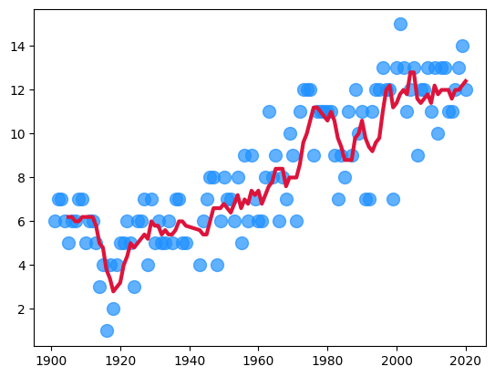

```python
plt.scatter(
    x=prize_every_year.index,
    y=prize_every_year.values,
    c='dodgerblue',
    alpha=0.7,
    s=100
)

plt.plot(prize_every_year.index,
         moving_average.values,
         c='crimson',
         linewidth=3)

plt.show()
```

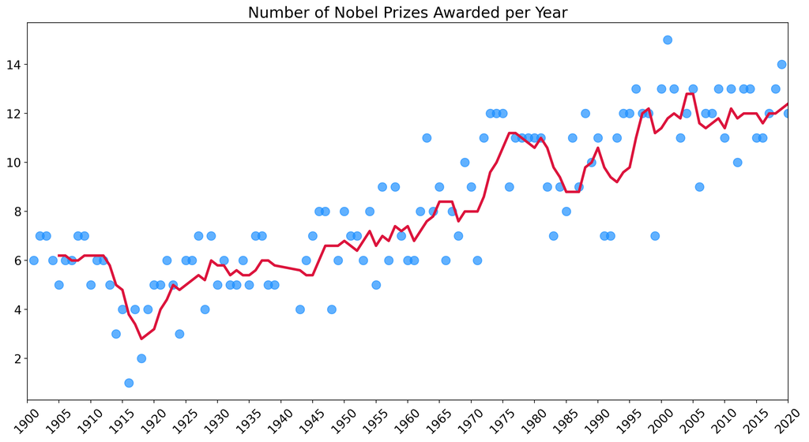

```python
plt.figure(figsize=(16,8), dpi=200)
plt.title('Number of Nobel Prizes Awarded per Year', fontsize=18)
plt.yticks(fontsize=14)
plt.xticks(ticks=np.arange(1900, 2021, step=5),
           fontsize=14,
           rotation=45)

ax = plt.gca() # get current axis
ax.set_xlim(1900, 2020)

ax.scatter(x=prize_every_year.index,
           y=prize_every_year.values,
           c='dodgerblue',
           alpha=0.7,
           s=100,)

ax.plot(prize_every_year.index,
        moving_average.values,
        c='crimson',
        linewidth=3,)

plt.show()
```

# Are More Prizes Shared Than Before?

**Challenge**: Investigate if more prizes are shared than before.

- Calculate the average prize share of the winners on a year by year basis.
- Calculate the 5 year rolling average of the percentage share.
- Copy-paste the cell from the chart you created above.
- Modify the code to add a secondary axis to your Matplotlib chart.
- Plot the rolling average of the prize share on this chart.
- See if you can invert the secondary y-axis to make the relationship even more clear.

```python
share_prize = df_data.groupby('year').agg({'share_pct': pd.Series.mean})
```

```python
share_price_avg = share_prize.rolling(window=5).mean()
```

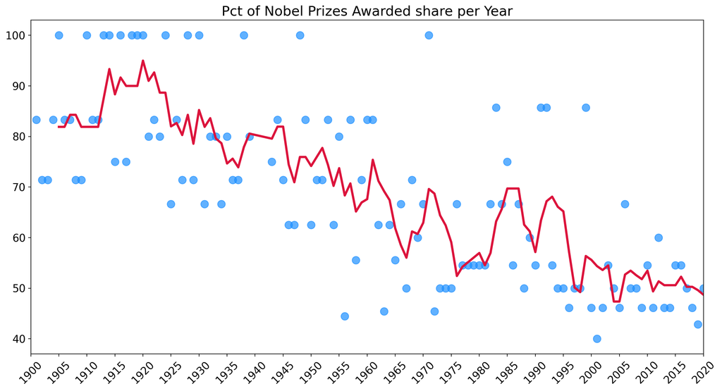

```python
plt.figure(figsize=(16,8), dpi=200)
plt.title('Pct of Nobel Prizes Awarded share per Year', fontsize=18)
plt.yticks(fontsize=14)
plt.xticks(ticks=np.arange(1900, 2021, step=5),
           fontsize=14,
           rotation=45)

ax = plt.gca() # get current axis
ax.set_xlim(1900, 2020)

ax.scatter(x=share_prize.index,
           y=share_prize.values,
           c='dodgerblue',
           alpha=0.7,
           s=100,)

ax.plot(share_prize.index,
        share_price_avg.values,
        c='crimson',
        linewidth=3,)

plt.show()
```

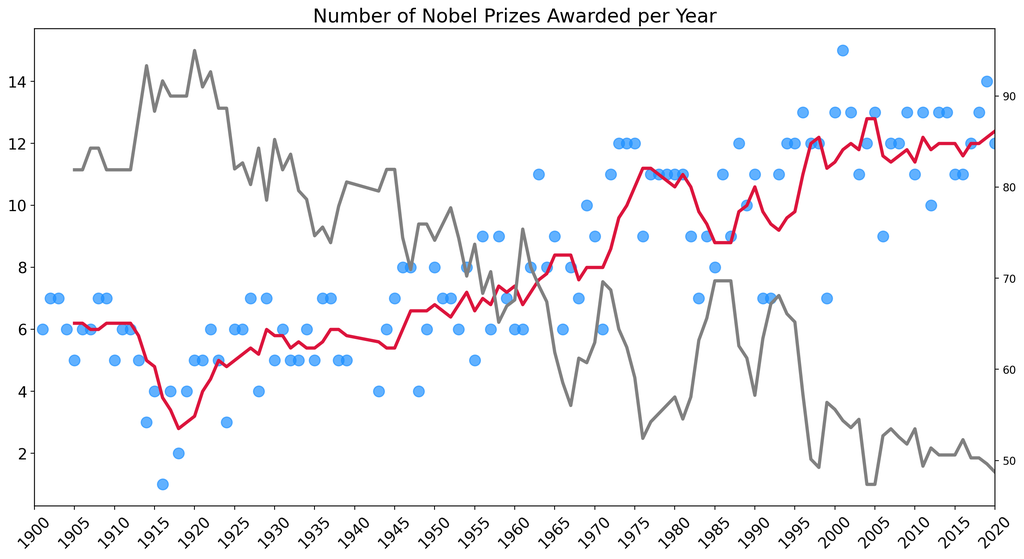

```python
plt.figure(figsize=(16,8), dpi=200)
plt.title('Number of Nobel Prizes Awarded per Year', fontsize=18)
plt.yticks(fontsize=14)
plt.xticks(ticks=np.arange(1900, 2021, step=5),
           fontsize=14,
           rotation=45)

ax1 = plt.gca() # get current axis
ax1.set_xlim(1900, 2020)
ax2 = ax1.twinx()

ax1.scatter(x=prize_every_year.index,
           y=prize_every_year.values,
           c='dodgerblue',
           alpha=0.7,
           s=100,)

ax1.plot(prize_every_year.index,
        moving_average.values,
        c='crimson',
        linewidth=3,)

ax2.plot(share_prize.index,
        share_price_avg.values,
        c='grey',
        linewidth=3,)

plt.show()
```

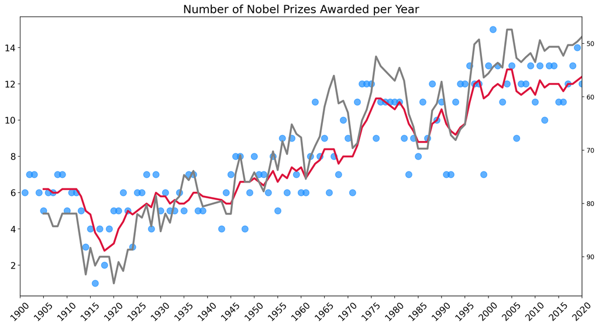

```python
plt.figure(figsize=(16,8), dpi=200)
plt.title('Number of Nobel Prizes Awarded per Year', fontsize=18)
plt.yticks(fontsize=14)
plt.xticks(ticks=np.arange(1900, 2021, step=5),
           fontsize=14,
           rotation=45)

ax1 = plt.gca() # get current axis
ax1.set_xlim(1900, 2020)
ax2 = ax1.twinx()
ax2.invert_yaxis()

ax1.scatter(x=prize_every_year.index,
           y=prize_every_year.values,
           c='dodgerblue',
           alpha=0.7,
           s=100,)

ax1.plot(prize_every_year.index,
        moving_average.values,
        c='crimson',
        linewidth=3,)

ax2.plot(share_prize.index,
        share_price_avg.values,
        c='grey',
        linewidth=3,)

plt.show()
```

# The Countries with the Most Nobel Prizes

**Challenge**:

- Create a Pandas DataFrame called `top20_countries` that has the two columns. The `prize` column should contain the total number of prizes won.

[figure not shown]

- Is it best to use `birth_country`, `birth_country_current` or `organization_country`?
- What are some potential problems when using `birth_country` or any of the others? Which column is the least problematic?
- Then use plotly to create a horizontal bar chart showing the number of prizes won by each country. Here's what you're after:

[figure not shown]

- What is the ranking for the top 20 countries in terms of the number of prizes?

```python
df_data.head()
```

|  | year | category | prize | motivation | prize_share | laureate_type | full_name | birth_date | birth_city | birth_country | birth_country_current | sex | organization_name | organization_city | organization_country | ISO | share_pct |
| --- | --- | --- | --- | --- | --- | --- | --- | --- | --- | --- | --- | --- | --- | --- | --- | --- | --- |
| 0 | 1901 | Chemistry | The Nobel Prize in Chemistry 1901 | "in recognition of the extraordinary services ... | 1/1 | Individual | Jacobus Henricus van 't Hoff | 1852-08-30 | Rotterdam | Netherlands | Netherlands | Male | Berlin University | Berlin | Germany | NLD | 100.00 |
| 1 | 1901 | Literature | The Nobel Prize in Literature 1901 | "in special recognition of his poetic composit... | 1/1 | Individual | Sully Prudhomme | 1839-03-16 | Paris | France | France | Male | NaN | NaN | NaN | FRA | 100.00 |
| 2 | 1901 | Medicine | The Nobel Prize in Physiology or Medicine 1901 | "for his work on serum therapy, especially its... | 1/1 | Individual | Emil Adolf von Behring | 1854-03-15 | Hansdorf (Lawice) | Prussia (Poland) | Poland | Male | Marburg University | Marburg | Germany | POL | 100.00 |
| 3 | 1901 | Peace | The Nobel Peace Prize 1901 | NaN | 1/2 | Individual | Frédéric Passy | 1822-05-20 | Paris | France | France | Male | NaN | NaN | NaN | FRA | 50.00 |
| 4 | 1901 | Peace | The Nobel Peace Prize 1901 | NaN | 1/2 | Individual | Jean Henry Dunant | 1828-05-08 | Geneva | Switzerland | Switzerland | Male | NaN | NaN | NaN | CHE | 50.00 |

```python
top20_countries = df_data.groupby('birth_country_current', as_index=False).agg({'prize': pd.Series.count})
```

```python
top20_countries = top20_countries.sort_values('prize', ascending=True)
```

```python
top20_countries = top20_countries[-20:]
```

```python
top20_countries_bar = px.bar(x=top20_countries.prize,
                             y=top20_countries.birth_country_current,
                             title='Top 20 Countries by Number of Prizes',
                             color=top20_countries.prize,
                             color_continuous_scale='Viridis')
top20_countries_bar.update_layout(xaxis_title='Number of Prizes',
                              yaxis_title='Country',
                              coloraxis_showscale=False)

top20_countries_bar.show()
```

# Use a Choropleth Map to Show the Number of Prizes Won by Country

- Create this choropleth map using [the plotly documentation](https://plotly.com/python/choropleth-maps/):

[figure not shown]

- Experiment with [plotly's available colours](https://plotly.com/python/builtin-colorscales/). I quite like the sequential colour `matter` on this map.

Hint: You'll need to use a 3 letter country code for each country.

```python
prize_per_country_map = df_data.groupby(['birth_country_current', 'ISO'], as_index=False).agg({'prize': pd.Series.count})
```

```python
prize_per_country_map
```

|  | birth_country_current | ISO | prize |
| --- | --- | --- | --- |
| 0 | Algeria | DZA | 2 |
| 1 | Argentina | ARG | 4 |
| 2 | Australia | AUS | 10 |
| 3 | Austria | AUT | 18 |
| 4 | Azerbaijan | AZE | 1 |
| ... | ... | ... | ... |
| 74 | United States of America | USA | 281 |
| 75 | Venezuela | VEN | 1 |
| 76 | Vietnam | VNM | 1 |
| 77 | Yemen | YEM | 1 |
| 78 | Zimbabwe | ZWE | 1 |

79 rows × 3 columns

```python
fig = px.choropleth(prize_per_country_map,
                    locations='ISO',
                    color='prize',
                    hover_name='birth_country_current',
                    color_continuous_scale='matter'
                    )

fig.update_layout(coloraxis_showscale=True)

fig.show()
```

# In Which Categories are the Different Countries Winning Prizes?

**Challenge**: See if you can divide up the plotly bar chart you created above to show the which categories made up the total number of prizes. Here's what you're aiming for:

[figure not shown]

- In which category are Germany and Japan the weakest compared to the United States?
- In which category does Germany have more prizes than the UK?
- In which categories does France have more prizes than Germany?
- Which category makes up most of Australia's nobel prizes?
- Which category makes up half of the prizes in the Netherlands?
- Does the United States have more prizes in Economics than all of France? What about in Physics or Medicine?

The hard part is preparing the data for this chart!

*Hint*: Take a two-step approach. The first step is grouping the data by country and category. Then you can create a DataFrame that looks something like this:

[figure not shown]

```python
cat_country = df_data.groupby(['birth_country_current', 'category'], as_index=False).agg({'prize':pd.Series.count})
```

```python
cat_country.sort_values(by='prize', ascending=False, inplace=True)
```

```python
cat_country
```

|  | birth_country_current | category | prize |
| --- | --- | --- | --- |
| 204 | United States of America | Medicine | 78 |
| 206 | United States of America | Physics | 70 |
| 201 | United States of America | Chemistry | 55 |
| 202 | United States of America | Economics | 49 |
| 198 | United Kingdom | Medicine | 28 |
| ... | ... | ... | ... |
| 97 | Iraq | Peace | 1 |
| 99 | Ireland | Medicine | 1 |
| 100 | Ireland | Physics | 1 |
| 102 | Israel | Economics | 1 |
| 210 | Zimbabwe | Peace | 1 |

211 rows × 3 columns

```python
merged_df = pd.merge(cat_country, top20_countries, on='birth_country_current')
```

```python
merged_df.columns = ['Country', 'Category', 'cat_prize', 'Total Prize']
```

```python
merged_df.sort_values(by='Total Prize', inplace=True)
```

```python
merged_df
```

|  | Country | Category | cat_prize | Total Prize |
| --- | --- | --- | --- | --- |
| 109 | India | Physics | 1 | 9 |
| 108 | India | Peace | 1 | 9 |
| 88 | Belgium | Peace | 3 | 9 |
| 89 | Belgium | Medicine | 3 | 9 |
| 90 | Belgium | Chemistry | 1 | 9 |
| ... | ... | ... | ... | ... |
| 4 | United States of America | Peace | 19 | 281 |
| 3 | United States of America | Economics | 49 | 281 |
| 2 | United States of America | Chemistry | 55 | 281 |
| 1 | United States of America | Physics | 70 | 281 |
| 0 | United States of America | Medicine | 78 | 281 |

110 rows × 4 columns

```python
fig = px.bar(data_frame=merged_df,
             x='cat_prize',
             y='Country',
             color='Category')

fig.update_layout(xaxis_title='Number of Prize',
                  yaxis_title = 'Country')

fig.show()
```

### Number of Prizes Won by Each Country Over Time

- When did the United States eclipse every other country in terms of the number of prizes won?
- Which country or countries were leading previously?
- Calculate the cumulative number of prizes won by each country in every year. Again, use the `birth_country_current` of the winner to calculate this.
- Create a [plotly line chart](https://plotly.com/python/line-charts/) where each country is a coloured line.

```python
df_data.head(1)
```

|  | year | category | prize | motivation | prize_share | laureate_type | full_name | birth_date | birth_city | birth_country | birth_country_current | sex | organization_name | organization_city | organization_country | ISO | share_pct |
| --- | --- | --- | --- | --- | --- | --- | --- | --- | --- | --- | --- | --- | --- | --- | --- | --- | --- |
| 0 | 1901 | Chemistry | The Nobel Prize in Chemistry 1901 | "in recognition of the extraordinary services ... | 1/1 | Individual | Jacobus Henricus van 't Hoff | 1852-08-30 | Rotterdam | Netherlands | Netherlands | Male | Berlin University | Berlin | Germany | NLD | 100.00 |

```python
when_us_lead_the_world = df_data.groupby(['birth_country_current', 'year'], as_index=False).agg({'prize': pd.Series.count})
```

```python
when_us_lead_the_world
```

|  | birth_country_current | year | prize |
| --- | --- | --- | --- |
| 0 | Algeria | 1957 | 1 |
| 1 | Algeria | 1997 | 1 |
| 2 | Argentina | 1936 | 1 |
| 3 | Argentina | 1947 | 1 |
| 4 | Argentina | 1980 | 1 |
| ... | ... | ... | ... |
| 622 | United States of America | 2020 | 7 |
| 623 | Venezuela | 1980 | 1 |
| 624 | Vietnam | 1973 | 1 |
| 625 | Yemen | 2011 | 1 |
| 626 | Zimbabwe | 1960 | 1 |

627 rows × 3 columns

```python
when_us_lead_the_world = when_us_lead_the_world.groupby(by=['birth_country_current',
                                              'year']).sum().groupby(level=[0]).cumsum()
when_us_lead_the_world.reset_index(inplace=True)
```

```python
fig = px.line(data_frame=when_us_lead_the_world,
              x='year',
              y='prize',
              color='birth_country_current')

fig.update_layout(yaxis_title = 'Number of Prizes',
                  xaxis_title = 'Year')
fig.show()
```

# What are the Top Research Organisations?

**Challenge**: Create a bar chart showing the organisations affiliated with the Nobel laureates. It should looks something like this:

[figure not shown]

- Which organisations make up the top 20?
- How many Nobel prize winners are affiliated with the University of Chicago and Harvard University?

```python
df_data.head(1)
```

|  | year | category | prize | motivation | prize_share | laureate_type | full_name | birth_date | birth_city | birth_country | birth_country_current | sex | organization_name | organization_city | organization_country | ISO | share_pct |
| --- | --- | --- | --- | --- | --- | --- | --- | --- | --- | --- | --- | --- | --- | --- | --- | --- | --- |
| 0 | 1901 | Chemistry | The Nobel Prize in Chemistry 1901 | "in recognition of the extraordinary services ... | 1/1 | Individual | Jacobus Henricus van 't Hoff | 1852-08-30 | Rotterdam | Netherlands | Netherlands | Male | Berlin University | Berlin | Germany | NLD | 100.00 |

```python
top_org = df_data.groupby('organization_name', as_index=False).agg({'prize': pd.Series.count})
```

```python
top_org = top_org.sort_values(by='prize', ascending=True)[-20:]
```

```python
top_org
```

|  | organization_name | prize |
| --- | --- | --- |
| 79 | Institut Pasteur | 7 |
| 109 | London University | 7 |
| 67 | Harvard Medical School | 7 |
| 192 | University College London | 7 |
| 40 | Cornell University | 8 |
| 12 | Bell Laboratories | 8 |
| 258 | Yale University | 9 |
| 111 | MRC Laboratory of Molecular Biology | 10 |
| 222 | University of Oxford | 12 |
| 152 | Rockefeller University | 13 |
| 119 | Max-Planck-Institut | 13 |
| 146 | Princeton University | 15 |
| 38 | Columbia University | 17 |
| 26 | California Institute of Technology (Caltech) | 17 |
| 197 | University of Cambridge | 18 |
| 198 | University of Chicago | 20 |
| 117 | Massachusetts Institute of Technology (MIT) | 21 |
| 167 | Stanford University | 23 |
| 68 | Harvard University | 29 |
| 196 | University of California | 40 |

```python
fig = px.bar(data_frame=top_org,
             x='prize',
             y='organization_name',
             title='Top 20 Research Insitutions by Number of Prizes',
             color='prize')

fig.update_layout(yaxis_title='Organizaton',
                  xaxis_title='Number of Prize')

fig.show()
```

# Which Cities Make the Most Discoveries?

Where do major discoveries take place?

**Challenge**:

- Create another plotly bar chart graphing the top 20 organisation cities of the research institutions associated with a Nobel laureate.
- Where is the number one hotspot for discoveries in the world?
- Which city in Europe has had the most discoveries?

```python
df_data.head(1)
```

|  | year | category | prize | motivation | prize_share | laureate_type | full_name | birth_date | birth_city | birth_country | birth_country_current | sex | organization_name | organization_city | organization_country | ISO | share_pct |
| --- | --- | --- | --- | --- | --- | --- | --- | --- | --- | --- | --- | --- | --- | --- | --- | --- | --- |
| 0 | 1901 | Chemistry | The Nobel Prize in Chemistry 1901 | "in recognition of the extraordinary services ... | 1/1 | Individual | Jacobus Henricus van 't Hoff | 1852-08-30 | Rotterdam | Netherlands | Netherlands | Male | Berlin University | Berlin | Germany | NLD | 100.00 |

```python
df_data.dropna(inplace=True)
df_data.isna().any()
```

```
year                     False
category                 False
prize                    False
motivation               False
prize_share              False
laureate_type            False
full_name                False
birth_date               False
birth_city               False
birth_country            False
birth_country_current    False
sex                      False
organization_name        False
organization_city        False
organization_country     False
ISO                      False
share_pct                False
dtype: bool
```

```python
top20_cities = df_data.groupby(['organization_city'], as_index=False).agg({'prize': pd.Series.count})
```

```python
top20_cities = top20_cities.sort_values(by='prize', ascending=True)[-20:]
```

```python
top20_cities
```

|  | organization_city | prize |
| --- | --- | --- |
| 63 | Göttingen | 8 |
| 183 | Zurich | 8 |
| 69 | Heidelberg | 9 |
| 117 | New Haven, CT | 9 |
| 108 | Munich | 9 |
| 22 | Boston, MA | 9 |
| 106 | Moscow | 10 |
| 154 | Stockholm | 10 |
| 124 | Oxford | 12 |
| 13 | Berlin | 12 |
| 127 | Pasadena, CA | 16 |
| 132 | Princeton, NJ | 19 |
| 38 | Chicago, IL | 20 |
| 12 | Berkeley, CA | 21 |
| 126 | Paris | 24 |
| 153 | Stanford, CA | 24 |
| 90 | London | 27 |
| 32 | Cambridge | 31 |
| 119 | New York, NY | 44 |
| 33 | Cambridge, MA | 49 |

```python
fig = px.bar(data_frame=top20_cities,
             x='prize',
             y='organization_city',
             color='prize',
             title='Which city has won the most Nobel prize?',
             color_continuous_scale=px.colors.sequential.Plasma,)

fig.update_layout(xaxis_title='Number of Prizes',
                  yaxis_title='City')

fig.show()
```

# Where are Nobel Laureates Born? Chart the Laureate Birth Cities

**Challenge**:

- Create a plotly bar chart graphing the top 20 birth cities of Nobel laureates.
- Use a named colour scale called `Plasma` for the chart.
- What percentage of the United States prizes came from Nobel laureates born in New York?
- How many Nobel laureates were born in London, Paris and Vienna?
- Out of the top 5 cities, how many are in the United States?

```python
df_data.head(1)
```

|  | year | category | prize | motivation | prize_share | laureate_type | full_name | birth_date | birth_city | birth_country | birth_country_current | sex | organization_name | organization_city | organization_country | ISO | share_pct |
| --- | --- | --- | --- | --- | --- | --- | --- | --- | --- | --- | --- | --- | --- | --- | --- | --- | --- |
| 0 | 1901 | Chemistry | The Nobel Prize in Chemistry 1901 | "in recognition of the extraordinary services ... | 1/1 | Individual | Jacobus Henricus van 't Hoff | 1852-08-30 | Rotterdam | Netherlands | Netherlands | Male | Berlin University | Berlin | Germany | NLD | 100.00 |

```python
birth_city_prize = df_data.groupby('birth_city', as_index=False).agg({'prize':pd.Series.count})
```

```python
top20_birth_city_prize = birth_city_prize.sort_values(by='prize')[-20:]
```

```python
fig = px.bar(data_frame=top20_birth_city_prize,
             y='birth_city',
             x='prize',
             color='prize',
             title='Where is the most talent born?')

fig.update_layout(xaxis_title='Prize',
                  yaxis_title='City')

fig.show()
```

# Plotly Sunburst Chart: Combine Country, City, and Organisation

**Challenge**:

- Create a DataFrame that groups the number of prizes by organisation.
- Then use the [plotly documentation to create a sunburst chart](https://plotly.com/python/sunburst-charts/)
- Click around in your chart, what do you notice about Germany and France?

Here's what you're aiming for:

[figure not shown]

```python
df_data.head(1)
```

|  | year | category | prize | motivation | prize_share | laureate_type | full_name | birth_date | birth_city | birth_country | birth_country_current | sex | organization_name | organization_city | organization_country | ISO | share_pct |
| --- | --- | --- | --- | --- | --- | --- | --- | --- | --- | --- | --- | --- | --- | --- | --- | --- | --- |
| 0 | 1901 | Chemistry | The Nobel Prize in Chemistry 1901 | "in recognition of the extraordinary services ... | 1/1 | Individual | Jacobus Henricus van 't Hoff | 1852-08-30 | Rotterdam | Netherlands | Netherlands | Male | Berlin University | Berlin | Germany | NLD | 100.00 |

```python
org_brunsun = df_data.groupby(['organization_name','organization_country', 'organization_city'], as_index=False).agg({'prize':pd.Series.count})
```

```python
org_brunsun.head()
```

|  | organization_name | organization_country | organization_city | prize |
| --- | --- | --- | --- | --- |
| 0 | A.F. Ioffe Physico-Technical Institute | Russia | St. Petersburg | 1 |
| 1 | Aarhus University | Denmark | Aarhus | 1 |
| 2 | Academy of Sciences | Russia | Moscow | 3 |
| 3 | Amsterdam University | Netherlands | Amsterdam | 2 |
| 4 | Argonne National Laboratory | United States of America | Argonne, IL | 1 |

```python
org_brunsun.sort_values(by='prize', ascending=False)
```

|  | organization_name | organization_country | organization_city | prize |
| --- | --- | --- | --- | --- |
| 71 | Harvard University | United States of America | Cambridge, MA | 28 |
| 185 | Stanford University | United States of America | Stanford, CA | 23 |
| 121 | Massachusetts Institute of Technology (MIT) | United States of America | Cambridge, MA | 21 |
| 221 | University of Chicago | United States of America | Chicago, IL | 20 |
| 214 | University of California | United States of America | Berkeley, CA | 19 |
| ... | ... | ... | ... | ... |
| 120 | Marine Biological Laboratory (MBL) | United States of America | Woods Hole, MA | 1 |
| 122 | Max-Planck Institut | Germany | Berlin | 1 |
| 124 | Max-Planck Institut | Germany | Heidelberg | 1 |
| 125 | Max-Planck-Institut | Germany | Berlin | 1 |
| 289 | École municipale de physique et de chimie indu... | France | Paris | 1 |

290 rows × 4 columns

```python
fig = px.sunburst(data_frame=org_brunsun,
                  path=['organization_country', 'organization_city','organization_name'],
                  values='prize')

fig.show()
```

# Patterns in the Laureate Age at the Time of the Award

How Old Are the Laureates When the Win the Prize?

**Challenge**: Calculate the age of the laureate in the year of the ceremony and add this as a column called `winning_age` to the `df_data` DataFrame. Hint: you can use [this](https://pandas.pydata.org/pandas-docs/stable/reference/api/pandas.Series.dt.html) to help you.

```python
df_data.head(1)
```

|  | year | category | prize | motivation | prize_share | laureate_type | full_name | birth_date | birth_city | birth_country | birth_country_current | sex | organization_name | organization_city | organization_country | ISO | share_pct |
| --- | --- | --- | --- | --- | --- | --- | --- | --- | --- | --- | --- | --- | --- | --- | --- | --- | --- |
| 0 | 1901 | Chemistry | The Nobel Prize in Chemistry 1901 | "in recognition of the extraordinary services ... | 1/1 | Individual | Jacobus Henricus van 't Hoff | 1852-08-30 | Rotterdam | Netherlands | Netherlands | Male | Berlin University | Berlin | Germany | NLD | 100.00 |

```python
df_data.info()
```

```
<class 'pandas.core.frame.DataFrame'>
Int64Index: 698 entries, 0 to 961
Data columns (total 17 columns):
 #   Column                 Non-Null Count  Dtype
---  ------                 --------------  -----
 0   year                   698 non-null    int64
 1   category               698 non-null    object
 2   prize                  698 non-null    object
 3   motivation             698 non-null    object
 4   prize_share            698 non-null    object
 5   laureate_type          698 non-null    object
 6   full_name              698 non-null    object
 7   birth_date             698 non-null    datetime64[ns]
 8   birth_city             698 non-null    object
 9   birth_country          698 non-null    object
 10  birth_country_current  698 non-null    object
 11  sex                    698 non-null    object
 12  organization_name      698 non-null    object
 13  organization_city      698 non-null    object
 14  organization_country   698 non-null    object
 15  ISO                    698 non-null    object
 16  share_pct              698 non-null    float64
dtypes: datetime64[ns](1), float64(1), int64(1), object(14)
memory usage: 98.2+ KB
```

```python
birth_year = df_data['birth_date'].dt.year
```

```python
df_data['winning_age'] = df_data.year - birth_year
```

```python
df_data.sample(1)
```

|  | year | category | prize | motivation | prize_share | laureate_type | full_name | birth_date | birth_city | birth_country | birth_country_current | sex | organization_name | organization_city | organization_country | ISO | share_pct | winning_age |
| --- | --- | --- | --- | --- | --- | --- | --- | --- | --- | --- | --- | --- | --- | --- | --- | --- | --- | --- |
| 755 | 2003 | Physics | The Nobel Prize in Physics 2003 | "for pioneering contributions to the theory of... | 1/3 | Individual | Alexei A. Abrikosov | 1928-06-25 | Moscow | Union of Soviet Socialist Republics (Russia) | Russia | Male | Argonne National Laboratory | Argonne, IL | United States of America | RUS | 33.33 | 75 |

### Who were the oldest and youngest winners?

**Challenge**:

- What are the names of the youngest and oldest Nobel laureate?
- What did they win the prize for?
- What is the average age of a winner?
- 75% of laureates are younger than what age when they receive the prize?
- Use Seaborn to [create histogram](https://seaborn.pydata.org/generated/seaborn.histplot.html) to visualise the distribution of laureate age at the time of winning. Experiment with the number of `bins` to see how the visualisation changes.

```python
df_data.sort_values(by='winning_age', ascending=False).head(1)
```

|  | year | category | prize | motivation | prize_share | laureate_type | full_name | birth_date | birth_city | birth_country | birth_country_current | sex | organization_name | organization_city | organization_country | ISO | share_pct | winning_age |
| --- | --- | --- | --- | --- | --- | --- | --- | --- | --- | --- | --- | --- | --- | --- | --- | --- | --- | --- |
| 937 | 2019 | Chemistry | The Nobel Prize in Chemistry 2019 | “for the development of lithium-ion batteries” | 1/3 | Individual | John Goodenough | 1922-07-25 | Jena | Germany | Germany | Male | University of Texas | Austin TX | United States of America | DEU | 33.33 | 97 |

```python
df_data.sort_values(by='winning_age', ascending=True).head(1)
```

|  | year | category | prize | motivation | prize_share | laureate_type | full_name | birth_date | birth_city | birth_country | birth_country_current | sex | organization_name | organization_city | organization_country | ISO | share_pct | winning_age |
| --- | --- | --- | --- | --- | --- | --- | --- | --- | --- | --- | --- | --- | --- | --- | --- | --- | --- | --- |
| 85 | 1915 | Physics | The Nobel Prize in Physics 1915 | "for their services in the analysis of crystal... | 1/2 | Individual | William Lawrence Bragg | 1890-03-31 | Adelaide | Australia | Australia | Male | Victoria University | Manchester | United Kingdom | AUS | 50.00 | 25 |

### Descriptive Statistics for the Laureate Age at Time of Award

- Calculate the descriptive statistics for the age at the time of the award.
- Then visualise the distribution in the form of a histogram using [Seaborn's .histplot() function](https://seaborn.pydata.org/generated/seaborn.histplot.html).
- Experiment with the `bin` size. Try 10, 20, 30, and 50.

```python
df_data['winning_age'].describe()
```

```
count   698.00
mean     58.81
std      12.56
min      25.00
25%      49.25
50%      58.50
75%      68.00
max      97.00
Name: winning_age, dtype: float64
```

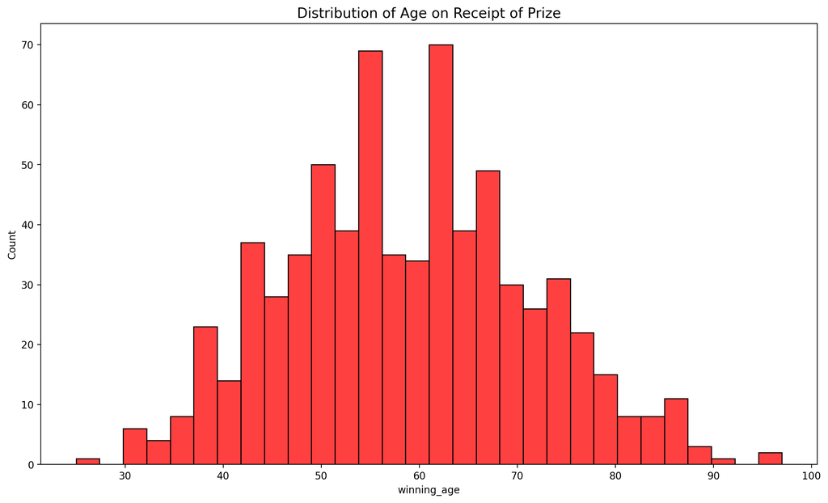

```python
plt.figure(figsize=(14,8), dpi=200)
sns.histplot(data=df_data, x='winning_age', bins=30,color='red')
plt.xlabel=('Age')
plt.title('Distribution of Age on Receipt of Prize', fontsize=14)
plt.show()
```

### Age at Time of Award throughout History

Are Nobel laureates being nominated later in life than before? Have the ages of laureates at the time of the award increased or decreased over time?

**Challenge**

- Use Seaborn to [create a .regplot](https://seaborn.pydata.org/generated/seaborn.regplot.html?highlight=regplot#seaborn.regplot) with a trendline.
- Set the `lowess` parameter to `True` to show a moving average of the linear fit.
- According to the best fit line, how old were Nobel laureates in the years 1900-1940 when they were awarded the prize?
- According to the best fit line, what age would it predict for a Nobel laureate in 2020?

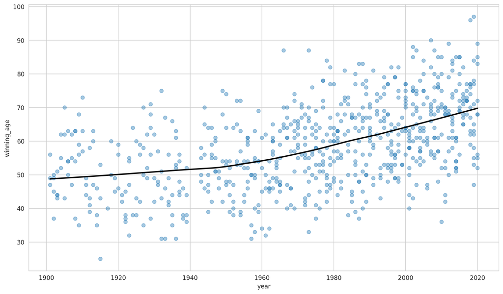

```python
plt.figure(figsize=(14,8), dpi=200)
with sns.axes_style('whitegrid'):
    sns.regplot(data=df_data,
                x='year',
                y='winning_age',
                lowess=True,
                scatter_kws={'alpha': 0.4},
                line_kws={'color': 'black'})
plt.show()
```

### Winning Age Across the Nobel Prize Categories

How does the age of laureates vary by category?

- Use Seaborn's [`.boxplot()`](https://seaborn.pydata.org/generated/seaborn.boxplot.html?highlight=boxplot#seaborn.boxplot) to show how the mean, quartiles, max, and minimum values vary across categories. Which category has the longest "whiskers"?
- In which prize category are the average winners the oldest?
- In which prize category are the average winners the youngest?

```python
df_data.groupby('category', as_index=False).agg({'winning_age':pd.Series.mean})
```

|  | category | winning_age |
| --- | --- | --- |
| 0 | Chemistry | 58.62 |
| 1 | Economics | 66.76 |
| 2 | Medicine | 58.48 |
| 3 | Physics | 56.13 |

```python
df_data['category'].nunique()
```

```
4
```

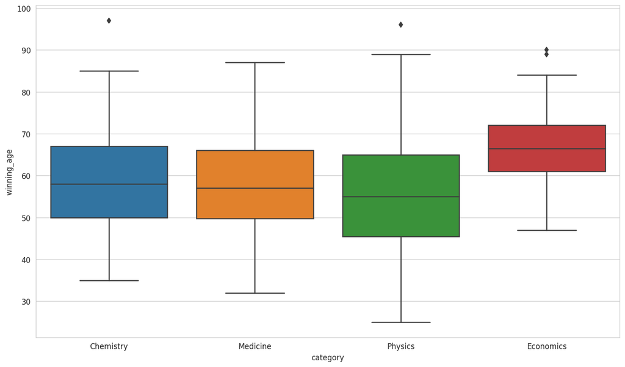

```python
plt.figure(figsize=(14,8), dpi=120)
with sns.axes_style('whitegrid'):
    sns.boxplot(data=df_data,
                x='category',
                y='winning_age')
plt.show()
```

**Challenge**

- Now use Seaborn's [`.lmplot()`](https://seaborn.pydata.org/generated/seaborn.lmplot.html?highlight=lmplot#seaborn.lmplot) and the `row` parameter to create 6 separate charts for each prize category. Again set `lowess` to `True`.
- What are the winning age trends in each category?
- Which category has the age trending up and which category has the age trending down?
- Is this `.lmplot()` telling a different story from the `.boxplot()`?
- Create another chart with Seaborn. This time use `.lmplot()` to put all 6 categories on the same chart using the `hue` parameter.

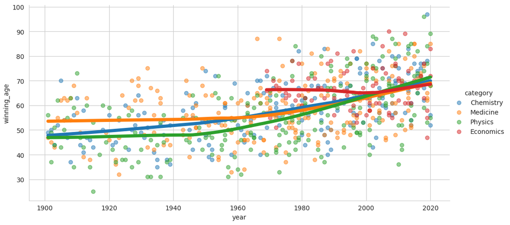

```python
plt.figure(figsize=(14,8), dpi=200)
with sns.axes_style('whitegrid'):
    sns.lmplot(data=df_data,
               y='winning_age',
               x='year',
               hue='category',
               aspect=2,
               scatter_kws={'alpha': 0.5},
               line_kws = {'linewidth':5},
               lowess=True)
plt.show()
```